# Problem set 4, part I key: Competition

```r
library(package = "deSolve")
library(package = "viridis")
library(package = "phaseR")
```

## 1. Competition nullclines and trajectory

Below are a version of two-species competition equations
$$\begin{aligned}
\frac{\mathrm{d}N_1}{\mathrm{d}t} &= N_1\left(r_1 - \alpha _{11}N_1
- \alpha _{12}N_2\right) \\
\frac{\mathrm{d}N_2}{\mathrm{d}t} &= N_2\left(r_2 - \alpha _{22}N_2
- \alpha _{21}N_1\right)
\end{aligned}$$
where $N_i$ has is negatively affected by $N_j$ is $\alpha _{ij}$. The growth rates are $r_i$ and within-species (intraspecific competition) crowding effects are $\alpha _{ii}$.

For the following subquestions, I’d like for you to find the nullclines, plot them on a blank plot, and plot a few trajectories.

> 1.1
> $$\begin{aligned}
> \text{For }\frac{\mathrm{d}N_1}{\mathrm{d}t}:\\
> \frac{\mathrm{d}N_1}{\mathrm{d}t} &= 0 = N_1\left(r_1 - \alpha
> _{11}N_1 - \alpha _{12}N_2\right) \\
> \text{Trivial nullcline: }N^*_1 &= 0 \\
> 0 &= r_1 - \alpha _{11}N_1 - \alpha _{12}N_2 \\
> \alpha _{11}N_1 &= r_1 - \alpha _{12}N_2 \\
> \text{Second nullcline: }N_1^* &= \frac{r_1}{\alpha _{11}} -
> \frac{\alpha _{12}}{\alpha _{11}}N_2 \\
> \text{For }\frac{\mathrm{d}N_2}{\mathrm{d}t}:\\
> \frac{\mathrm{d}N_2}{\mathrm{d}t} &= 0 = N_2\left(r_2 - \alpha
> _{2}N_2 - \alpha _{21}N_1\right) \\
> \text{Trivial nullcline: }N^*_2 &= 0 \\
> 0 &= r_2 - \alpha _{22}N_2 - \alpha _{21}N_1 \\
> \alpha _{22}N_2 &= r_2 - \alpha _{21}N_1 \\
> \text{Second nullcline: }N_2^* &= \frac{r_2}{\alpha _{22}} -
> \frac{\alpha _{21}}{\alpha _{22}}N_1 \\
> \end{aligned}$$

> 1.2.

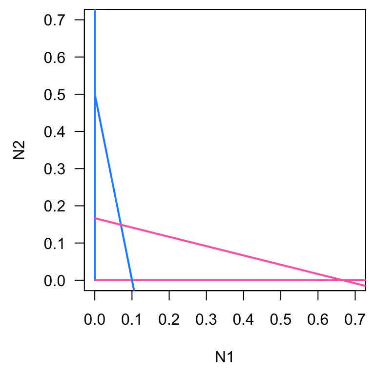

```r
# Create a parameter vector and a vector of "x-" (N1-) axis values
  parm_vec <- c(r1 = 0.1, r2 = 0.2, alpha11 = 1, alpha22 = 1.2, alpha12 = 0.2, alpha21 = 0.3)
  N1_vec <- seq(from = 0, to = 5, by = 0.1)
# Rearage N1 nullcline to put "y" (N2) on left-hand side and leave N2 nullcline as is
  N1_null <- parm_vec["r1"]/parm_vec["alpha12"] - parm_vec["alpha11"]/parm_vec["alpha12"]*N1_vec
  N2_null <- parm_vec["r2"]/parm_vec["alpha22"] - parm_vec["alpha21"]/parm_vec["alpha22"]*N1_vec
# Creat a blank plot
  par(mar = c(4.5, 4.5, 0.5, 0.5))
  plot(x = NA, type = "n", xlim = c(0, 0.7), ylim = c(0, 0.7), xlab = "N1", ylab = "N2", las = 1)
# Add trivial nullclines
  lines(x = c(0, 0), y = c(0, 1), lwd = 2, col = "dodgerblue")
  lines(x = c(0, 1), y = c(0, 0), lwd = 2, col = "hotpink")
# Add other nullclines
  lines(x = N1_vec, y = N1_null, lwd = 2, col = "dodgerblue")
  lines(x = N1_vec, y = N2_null, lwd = 2, col = "hotpink")
```

> 1.3.

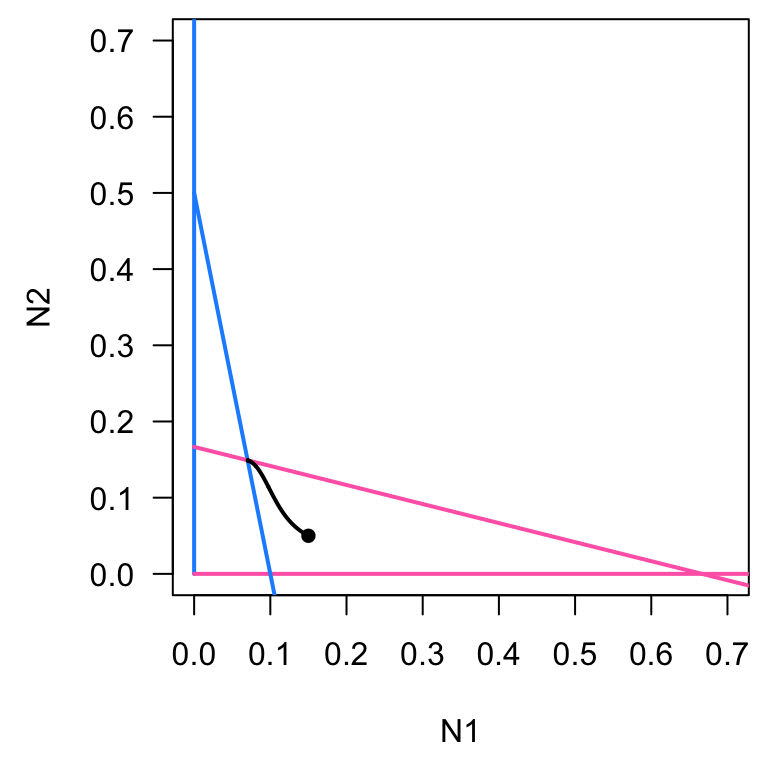

```r
# Same plot as above
  # Create a parameter vector and a vector of "x-" (N1-) axis values
    parm_vec <- c(r1 = 0.1, r2 = 0.2, alpha11 = 1, alpha22 = 1.2, alpha12 = 0.2, alpha21 = 0.3)
    N1_vec <- seq(from = 0, to = 5, by = 0.1)
  # Rearage N1 nullcline to put "y" (N2) on left-hand side and leave N2 nullcline as is
    N1_null <- parm_vec["r1"]/parm_vec["alpha12"] - parm_vec["alpha11"]/parm_vec["alpha12"]*N1_vec
    N2_null <- parm_vec["r2"]/parm_vec["alpha22"] - parm_vec["alpha21"]/parm_vec["alpha22"]*N1_vec
  # Creat a blank plot
    par(mar = c(4.5, 4.5, 0.5, 0.5))
    plot(x = NA, type = "n", xlim = c(0, 0.7), ylim = c(0, 0.7), xlab = "N1", ylab = "N2", las = 1)
  # Add trivial nullclines
    lines(x = c(0, 0), y = c(0, 1), lwd = 2, col = "dodgerblue")
    lines(x = c(0, 1), y = c(0, 0), lwd = 2, col = "hotpink")
  # Add other nullclines
    lines(x = N1_vec, y = N1_null, lwd = 2, col = "dodgerblue")
    lines(x = N1_vec, y = N2_null, lwd = 2, col = "hotpink")
# Numerically solve initial-values of N1(0) = 0.15 and N2(0) = 0.05
    compfun <- function(times, state, pars) {
      with(as.list(c(state, pars)), {
        dN1 <- r1*N1 - a11*N1*N1 - a12*N1*N2
        dN2 <- r2*N2 - a22*N2*N2 - a21*N2*N1
        return(list(c(dN1, dN2)))
      })
    }

  time_vec <- seq(from = 0, to = 100, by = 0.1)
  par_vec <- c(r1 = 0.1, r2 = 0.2, a11 = 1, a22 = 1.2, a12 = 0.2, a21 = 0.3)
  init_1 <- c(N1 = 0.15, N2 = 0.05)

  ode_1 <- ode(y = init_1, times = time_vec, func = compfun, parms = par_vec)

# Plot lines and a point at t = 0
  lines(x = ode_1[,2], ode_1[,3], lwd = 2)
  points(x = init_1[1], y = init_1[2], pch = 16)
```

> 1.4.

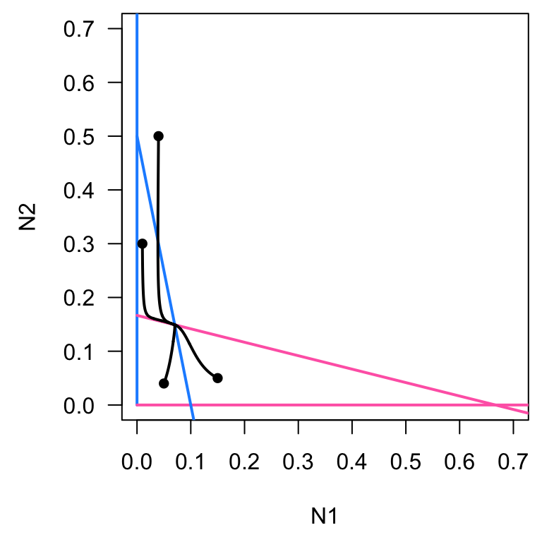

```r
 #Same plot as above
  # Create a parameter vector and a vector of "x-" (N1-) axis values
    parm_vec <- c(r1 = 0.1, r2 = 0.2, alpha11 = 1, alpha22 = 1.2, alpha12 = 0.2, alpha21 = 0.3)
    N1_vec <- seq(from = 0, to = 5, by = 0.1)
  # Rearage N1 nullcline to put "y" (N2) on left-hand side and leave N2 nullcline as is
    N1_null <- parm_vec["r1"]/parm_vec["alpha12"] - parm_vec["alpha11"]/parm_vec["alpha12"]*N1_vec
    N2_null <- parm_vec["r2"]/parm_vec["alpha22"] - parm_vec["alpha21"]/parm_vec["alpha22"]*N1_vec
  # Creat a blank plot
    par(mar = c(4.5, 4.5, 0.5, 0.5))
    plot(x = NA, type = "n", xlim = c(0, 0.7), ylim = c(0, 0.7), xlab = "N1", ylab = "N2", las = 1)
  # Add trivial nullclines
    lines(x = c(0, 0), y = c(0, 1), lwd = 2, col = "dodgerblue")
    lines(x = c(0, 1), y = c(0, 0), lwd = 2, col = "hotpink")
  # Add other nullclines
    lines(x = N1_vec, y = N1_null, lwd = 2, col = "dodgerblue")
    lines(x = N1_vec, y = N2_null, lwd = 2, col = "hotpink")
# Numerically solve initial-values of N1(0) = 0.15 and N2(0) = 0.05
    compfun <- function(times, state, pars) {
      with(as.list(c(state, pars)), {
        dN1 <- r1*N1 - a11*N1*N1 - a12*N1*N2
        dN2 <- r2*N2 - a22*N2*N2 - a21*N2*N1
        return(list(c(dN1, dN2)))
      })
    }

  time_vec <- seq(from = 0, to = 100, by = 0.1)
  par_vec <- c(r1 = 0.1, r2 = 0.2, a11 = 1, a22 = 1.2, a12 = 0.2, a21 = 0.3)
  init_1 <- c(N1 = 0.15, N2 = 0.05)

  ode_1 <- ode(y = init_1, times = time_vec, func = compfun, parms = par_vec)

# Plot lines and a point at t = 0
  lines(x = ode_1[,2], ode_1[,3], lwd = 2)
  points(x = init_1[1], y = init_1[2], pch = 16)
  init_2 <- c(N1 = 0.05, N2 = 0.04)
  init_3 <- c(N1 = 0.04, N2 = 0.5)
  init_4 <- c(N1 = 0.01, N2 = 0.3)

  ode_2 <- ode(y = init_2, times = time_vec, func = compfun, parms = par_vec)
  ode_3 <- ode(y = init_3, times = time_vec, func = compfun, parms = par_vec)
  ode_4 <- ode(y = init_4, times = time_vec, func = compfun, parms = par_vec)

# Plot lines and a point at t = 0
  lines(x = ode_2[,2], ode_2[,3], lwd = 2)
  points(x = init_2[1], y = init_2[2], pch = 16)
  lines(x = ode_3[,2], ode_3[,3], lwd = 2)
  points(x = init_3[1], y = init_3[2], pch = 16)
  lines(x = ode_4[,2], ode_4[,3], lwd = 2)
  points(x = init_4[1], y = init_4[2], pch = 16)
```

## 2. Competition nullclines and vector (flow) field

Now that you have plotted the isoclines and a trajectory, I want to show you a more general way of visualizing how populations are going to change, instead of just showing a single trajectory.

But I first want to re-introduce a phrase that we taught in ecology where we had the populations (stat variables) on the horizontal and vertical axes and we plotted the isoclines to show the population dynamics. We called these *phase planes*, and I am going to use that language over the next 6 weeks or so as we study two-dimensional systems.

OK, but we are going to further make these phase planes more generally interpretable by adding a (vector) field to the background. In sum, the field shows for a given set of densities of each variable (i) the direction that the populations will change to and (ii), often, the magnitude. Here is what it would looks like for the competition model:

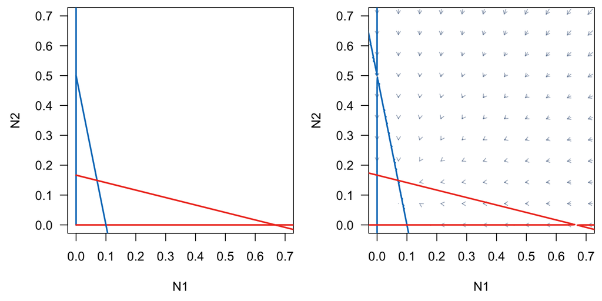

Looking at these two phase planes, it’s easy to see how much more information the vector field adds. Notice, too, that in some areas (e.g., where $N_1 = 0.7$ and $N_2 = 0.7$) we see arrows with long tails indicating that the rate of change is relatively high and other areas (e.g., around the positive equilibrium) the tails are so small you can’t even see them. Nevertheless, we can now qualitatively see how the populations are going to change through time—such a useful and, IMO, aesthetically-pleasing tool!

For this problem, I ask that you recreate what you did in problem 1, but using an R package that will plot both the isoclines and vector field for you 🤓. You’ll do this with a new package called `phaseR`, so you’ll need to load it from your library just like with `deSolve`. (Phaser, BTW, is a sound effect that you hear in a lot of music, including, what is one of the best openings of any music album ever, [*Shine on your crazy diamond (parts I—V)* by Pink Floyd](https://www.youtube.com/watch?v=cWGE9Gi0bB0) [at 3:39 you can hear the guitar with phaser]).

The easiest way to make a phase plane like mine is in three steps:

1. Make a blank plot
2. Use `flowField()` to add the vector field
3. Use `nullclines()` to add the nullclines

Pretty simple, right? It is in my opinion. This package has a few things that are slightly annoying that might cause your code not to work. Here’s a list of those:

- For both `flowField()` and `nullclines()` you need to specify the `xlim` and `ylim`
- In `ode()` the argument for your function is `func =` and in `flowField()` and `nullclines()` it’s `deriv =`
- In `ode()` the argument for your parameters is `parms =` and in `flowField()` and `nullclines()` it’s `parameters =`
- You **must** give `flowField()` and `nullclines()` the names of your state variables in the `state.names =` argument; e.g., `state.names = c("Roadrunner", "Wiley E. Coyote")`
- Each `flowField()` and `nullclines()`, when plotted, returns a bunch of data that you don’t need. You can suppress the printing of the output by assigning the function to some variable. I call mine `trash` like this, for example: `trash <- flowField(...)` where the arguments are filled in where the ellipses are.

And, I always recommend that you check the documentation for each of the functions `flowField()` and `nullclines()`. You’ll find them helpful, as it tells you how to change, for instance, the size of the arrowheads, the number of points in the vector field, opting to not plot the legend, etc.

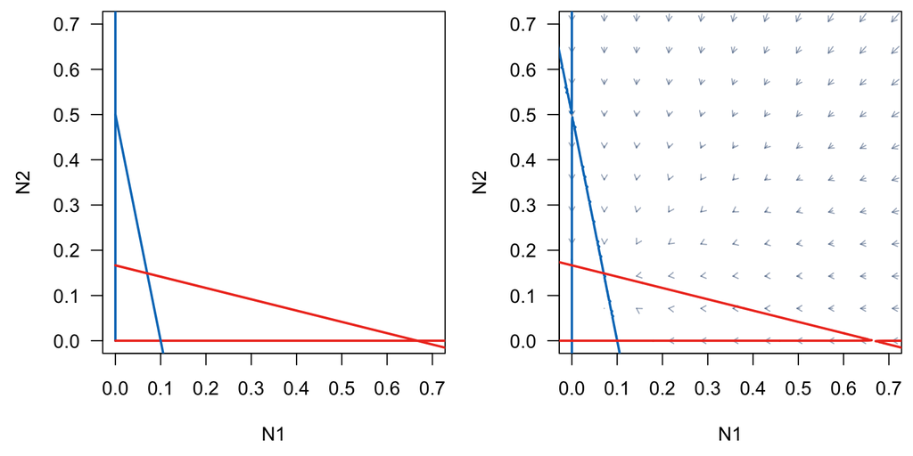

```r
# ode() set up
compfun <- function(times, state, pars) {
  with(as.list(c(state, pars)), {
    dN1 <- r1*N1 - a11*N1*N1 - a12*N1*N2
    dN2 <- r2*N2 - a22*N2*N2 - a21*N2*N1
    return(list(c(dN1, dN2)))
  })
}

time_vec <- seq(from = 0, to = 100, by = 0.1)
  r1 <- 0.1
  r2 <- 0.2
  a11 <- 1.0
  a22 <- 1.2
  a12 <- 0.2
  a21 <- 0.3
par_vec <- c(r1 = 0.1, r2 = 0.2, a11 = 1, a22 = 1.2, a12 = 0.2, a21 = 0.3)


# Plot isoclines
  par(mfrow = c(1, 2), mar = c(4.5, 4.5, 0.5, 0.5))
  # Blank plot
  plot(x = NA, type = "n", las = 1, xlab = "N1", ylab = "N2", xlim = c(0, 0.7), ylim = c(0, 0.7))

   # Trivial nullclines
  lines(x = c(0, 0), y = c(0, 1), col = "#007ac1", lwd = 2)
  lines(x = c(0, 1), y = c(0, 0), col = "#ef3b24", lwd = 2)

  # Non-trivial nullclines
  N1_vec <- seq(from = 0, to = 1)
  N1_null <- r1/a12 - a11/a12*N1_vec
  lines(x = N1_vec, y = N1_null, col = "#007ac1", lwd = 2)

  N2_null <- r2/a22 - a21/a22*N1_vec
  lines(x = N1_vec, y = N2_null, col = "#ef3b24", lwd = 2)

# Plot isoclines + vector field
  plot(x = NA, type = "n", las = 1, xlab = "N1", ylab = "N2", xlim = c(0, 0.7), ylim = c(0, 0.7))
  trash <- flowField(deriv = compfun, xlim = c(0, 1), ylim = c(0, 1), parameters = par_vec, state.names = c("N1", "N2"), arrow.type = "proportional", points = 15, col = "#002D6266")
  trash <- nullclines(deriv = compfun, xlim = c(-0.1, 1), ylim = c(-0.1, 1), parameters = par_vec, state.names = c("N1", "N2"), col = c("#007ac1", "#ef3b24"), lwd = 2, add.legend = F, points = 501)
```